# ITEC 620 - Group Project Proposal

Kogod School of Business

Binh Minh An Nguyen, Ahmed Malik

11/27/2021

## 0.1 Opening

I would like to give credits to my friend, also my teammate - Ahmed Malik - for his contributions throughout the group project. While the analysis was also contributed by other team members - Steve Rodriguez and Ho-Ah Kim.

The project was submitted during end of November 2021, and was editted by myself in January 2022.

# 1 Executive Summary

According to the International Association of Safe International Travel, approximately 38,000 people dies annually due to traffic accidents in the US (Q, A., 2021). Our objective is to draw actionable conclusions based on trends and causes of traffic accidents to better inform the public domain on potential significant causes and trends of traffic accidents and what can be done to mitigate the high number of accidents in the United States.

Our dataset, retrieved from Kaggle (Moosavi, 2021), contains approximately 46 distinct columns attributing to one dependent variable - the severity of accidents and observations totaling approximately 1.04 million. The high number of data points was crucial in selecting the data set due to its robustness and exploration potential.

The methodology used to analyze the data consisted of both descriptive and predictive models that allowed for valuable insight into the frequency and significant factors contributing to the cause of the accidents. Predictive models allowed for the analysis leading to the probability of certain variables being identified as the major causes of severe accidents. The most significant findings when applying descriptive and predictive methods are as follows:

Lastly, we use Holt Winter Model and predicted approximately 43,000 accidents for the first week of 2021.

# 2 Introduction

The problem of traffic accidents in the United States affects thousands of drivers every year. Not only cause significant traffic jams, but also death, and injuries which makes more than 20,000 people die on American roadways (Zipper, 2021). Besides, the other impacts follow up with traffic jams, death, and injuries, which are long-lasting emotional, physical, and sometimes financial burdens.

In the European Union, they dropped the accident rate by thirty-six percent between 2010 and 2020 and traffic deaths by making regulations and adjusting the restriction (Zipper, 2021). Reducing accidents is one of the crucial tasks for the United States. Therefore, the government’s data as a reference for making regulations and restrictions will be a valuable source. In this project, by analyzing the accidents dataset, we would like to provide the government’s data to provide solutions to reduce the accidents.

Our preliminary analysis of the dataset indicates leading variables related to the accidents’ severity, including the location of the accident, weather, time that accident occurred, and road conditions. By implementing descriptive and predictive methods on this dataset, we will find the correlation among the variables and determine the relationships between what events, conditions, and causing effects impact more on the accident.

We will use two descriptive methods to explore and overview our dataset. These two techniques are: (1) Measure of Frequency to identify the pattern of accident frequency by hours and to check which states have the highest rates of accidents over 2016-2020, (2) Association Rules to understand the likelihood of weather, locations, lighting factors that could cause different levels of severity.

For predictive methods, we will examine Logistic Regression and Classification Tree on the prediction of accident severities. Next, we will analyze the potential seasonality of historic data to predict the next 7-day car accident frequency.

At the end of the project, we will provide actionable insights and suggestions to help US Government reduce the accident rates and accident severities.

# 3 Data ETL

**Step 1** – A primary data wrangling was done in Excel before we imported the dataset to R. These transformations include inserting a zero value on blank cells under the wind_speed column if the wind_direction is calm. This is based on other existing combination values under these 2 columns. The total rows that had been revised is approximately 600,000 rows.

**Step 2** - Import the dataset to R using `read_csv()` function under the tidyverse package and assign it into a variable named accidents. Since our dataset has multiple logical variables, read_csv() functions will be more efficient and productive.

```r
accidents <- read_csv("~/Documents/Kogod - AU/Fall 2021/ITEC 620/Group Project/US_ Accident_calm_0.csv")
```

In this section, we will primarily clean up our data; while moving on to the Analysis section, we will conduct secondary data wrangling for each analysis technique, if necessary.

1. Select only 26 relevant attributes from the original dataset
2. Rename some of the columns/variables
3. Re-format the date and time columns, and extract the respective year, month, week, date from the **Start_Date** column

Since this dataset involves more than 1 million distinct observations - by **Accident_ID**, duplicate removal is not required. Instead, the new dataset will be saved into a variable named `accident_c`.

There were 34,680 rows dropped from the first wrangling process because of the improper date-time values under the **Start_Time** column in our original data.

**Step 3** - We identified cells containing multiple values under the column weather_condition. Such values observed are conflicting with the single-value criterion of a data frame. To address such issues, we use `separate_rows()` function to split the chunks and use pivot_wider() under the tidyverse package to set them up as new column names since these are weather conditions that potentially affect the outcome of an accident. The new dataset will then be assigned to a variable named `accident_pivot`.

Now, we have a new dataset `accident_pivot` with 103 variables. Now, we will clean up the column names for our productivity.

```r
names(accident_pivot) <- str_replace_all(names(accident_pivot), " ", "_")

accident_pivot <- accident_pivot %>% select_all(tolower)
```

# 4 Analysis

## 4.1 Descriptive Data

### 4.1.1 Measurement of Frequency

1. Count the number of each severity

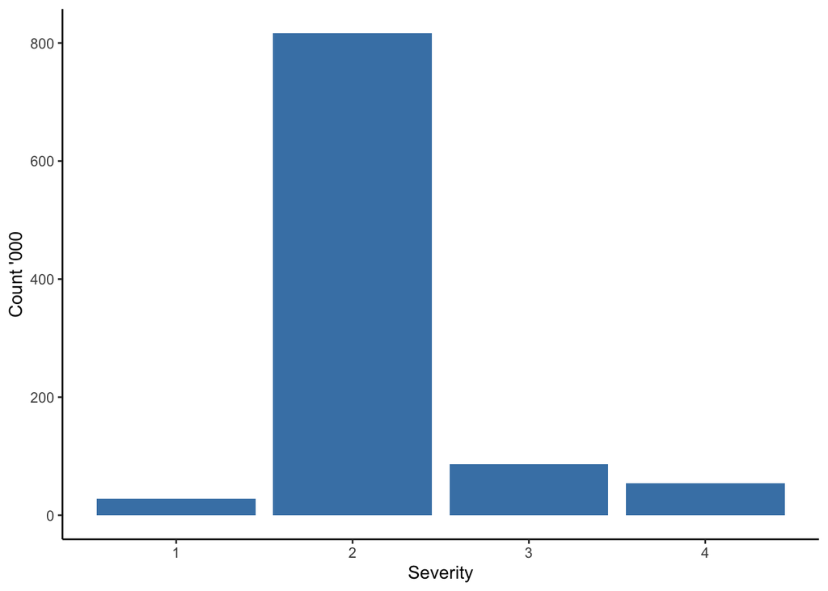

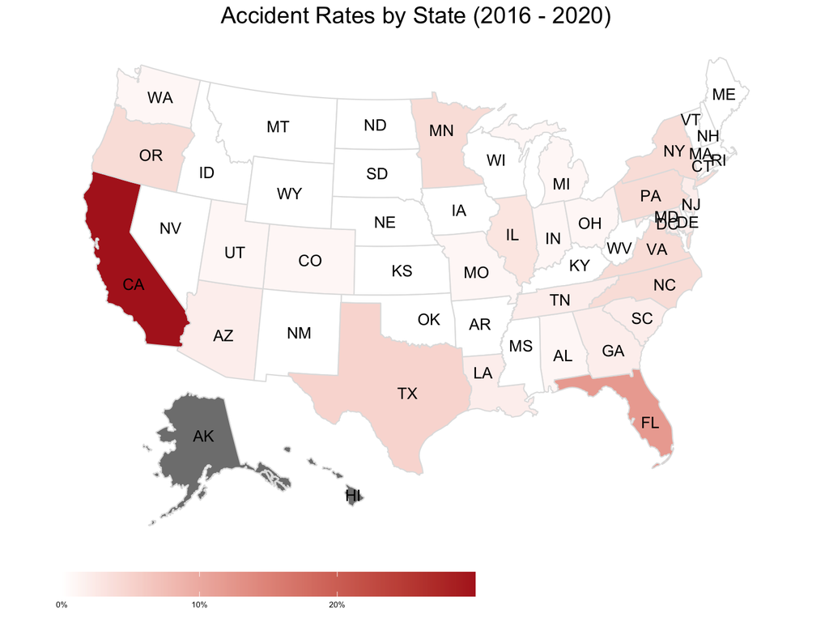

3. Accident rates by timing

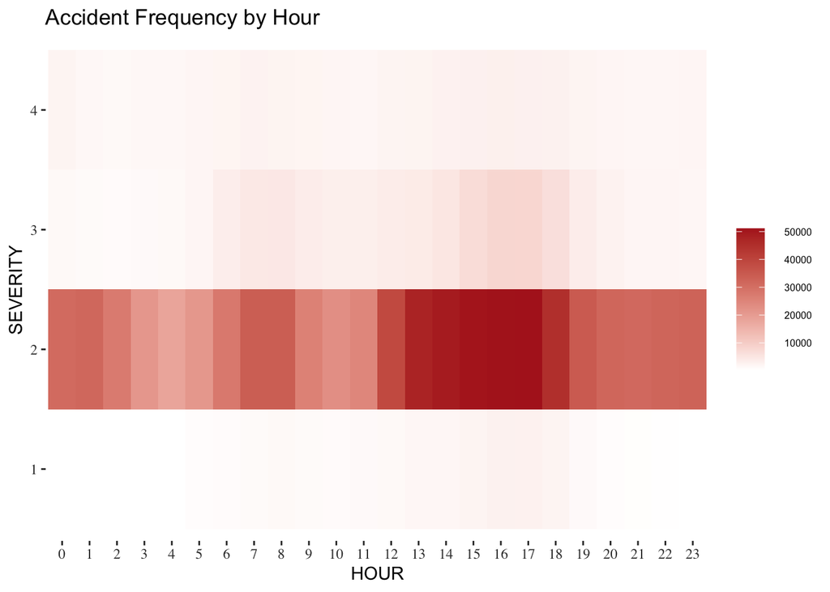

### 4.1.2 Association Rules

We are interested in learning which particular types of factors causing the most likelihood of each accident severity. Thus, from the initial dependent variable severity, we pick up and split each severity into new columns: severity_1, severity_2, severity_3, and severity_4. Similar process from the weather_condition will apply here. The new data with 107 columns is assigned to a variable named accident_binary.

Furthermore, we segmented the analysis to two separate scenarios which are highway and city since the dynamics of driving are different from each other. In addition, our dataset skewed more to highway accidents with approximately as twice as the city road accidents. Thus, splitting the dataset by road types will help us to gain more valuable insights on the cause of accidents.

1. Association Rules for Highway accident severities

**Step 1** - For highway category, location conditions such as amenity, crossing, stop, and railway become irrelevant. Thus, we removed these variables prior to running the association rules for the severity of highway accidents. The association rules will then be sorted by the lift ratio in descending order.

```r
accident_hway <- accident_binary %>%
  filter(is.highway == TRUE) %>%
  select(-amenity, -crossing, -stop, -railway, -is.highway)

hway_rules <- apriori(accident_hway, parameter = list(supp=0.0001, conf=0.0001))
```

```
## Apriori
##
## Parameter specification:
##  confidence minval smax arem  aval originalSupport maxtime support minlen
##       1e-04    0.1    1 none FALSE            TRUE       5   1e-04      1
##  maxlen target  ext
##      10  rules TRUE
##
## Algorithmic control:
##  filter tree heap memopt load sort verbose
##     0.1 TRUE TRUE  FALSE TRUE    2    TRUE
##
## Absolute minimum support count: 64
##
## set item appearances ...[0 item(s)] done [0.00s].
## set transactions ...[81 item(s), 649059 transaction(s)] done [0.13s].
## sorting and recoding items ... [47 item(s)] done [0.01s].
## creating transaction tree ... done [0.19s].
## checking subsets of size 1 2 3 4 5 done [0.00s].
## writing ... [2375 rule(s)] done [0.00s].
## creating S4 object  ... done [0.12s].
```

```r
hway_sorted <- sort(hway_rules, by = "lift")
```

**Step 2** - Subset the association rules for each severity at the `rhs` and select those rules with the lift ratio of at least 2.

```
##      lhs                                      rhs          support
## [1]  {traffic_signal,fair,is.day}          => {severity_1} 0.0041752753
## [2]  {traffic_signal,windy,is.day}         => {severity_1} 0.0001818017
## [3]  {traffic_signal,fair}                 => {severity_1} 0.0045203903
## [4]  {traffic_signal,windy}                => {severity_1} 0.0001818017
## [5]  {traffic_signal,is.day}               => {severity_1} 0.0068391317
## [6]  {traffic_signal,mostly_cloudy,is.day} => {severity_1} 0.0010615368
## [7]  {traffic_signal,cloudy,is.day}        => {severity_1} 0.0005808409
## [8]  {traffic_signal}                      => {severity_1} 0.0073367752
## [9]  {traffic_signal,mostly_cloudy}        => {severity_1} 0.0011185424
## [10] {traffic_signal,partly_cloudy,is.day} => {severity_1} 0.0005777595
## [11] {traffic_signal,light_rain,is.day}    => {severity_1} 0.0002249410
## [12] {station,traffic_signal,is.day}       => {severity_1} 0.0001818017
## [13] {traffic_signal,partly_cloudy}        => {severity_1} 0.0006116547
## [14] {station,fair,is.day}                 => {severity_1} 0.0001186333
```

[output cut: 27 more lines]

- **Severity 1**: the highest rule is *{traffic_signal, fair, is.day}* with the highest lift ratio of 8.871098. The variables of traffic signal, daytime, cloudy, windy, and rain are the most frequently shown among the rules as causing effects for Severity 1.
- **Step 3** - As we filter the association rules with a lift ratio being equal or more than 2, seems like there was no rules returned. Thus, for this section only, we will decrease the criterion of lift ratio for the severity 2.

```
##      lhs                    rhs               support confidence     coverage     lift  count
## [1]  {junction,
##       smoke,
##       is.day}            => {severity_2} 0.0001864237  0.9918033 0.0001879644 1.201788    121
## [2]  {junction,
##       smoke}             => {severity_2} 0.0003343302  0.9774775 0.0003420336 1.184429    217
## [3]  {haze,
##       windy}             => {severity_2} 0.0001694761  0.9649123 0.0001756389 1.169203    110
## [4]  {haze,
##       windy,
##       is.day}            => {severity_2} 0.0001247961  0.9642857 0.0001294181 1.168444     81
## [5]  {blowing_snow}      => {severity_2} 0.0001633134  0.9464286 0.0001725575 1.146806    106
## [6]  {smoke}             => {severity_2} 0.0020722307  0.9392458 0.0022062709 1.138103   1345
## [7]  {blowing_snow,
##       is.day}            => {severity_2} 0.0001155519  0.9375000 0.0001232554 1.135987     75
## [8]  {smoke,
##       is.day}            => {severity_2} 0.0012094432  0.9257075 0.0013065068 1.121698    785
## [9]  {haze}              => {severity_2} 0.0104951938  0.9109388 0.0115212947 1.103803   6812
## [10] {snow,
##       windy}             => {severity_2} 0.0002465107  0.9090909 0.0002711618 1.101564    160
## [11] {patches_of_fog}    => {severity_2} 0.0003682254  0.9087452 0.0004052020 1.101145    239
## [12] {wintry_mix}        => {severity_2} 0.0010276416  0.9087193 0.0011308679 1.101113    667
## [13] {n/a_precipitation} => {severity_2} 0.0003250860  0.9055794 0.0003589812 1.097309    211
## [14] {junction,
##       wintry_mix}        => {severity_2} 0.0001032264  0.9054054 0.0001140112 1.097098     67
## [15] {light_snow,
##       windy}             => {severity_2} 0.0008843572  0.9053628 0.0009767987 1.097046    574
## [16] {wintry_mix,
##       is.day}            => {severity_2} 0.0004252310  0.9049180 0.0004699111 1.096507    276
## [17] {blowing_dust}      => {severity_2} 0.0001124705  0.9012346 0.0001247961 1.092044     73
## [18] {blowing_dust,
##       is.day}            => {severity_2} 0.0001093891  0.8987342 0.0001217147 1.089014     71
## [19] {junction,
##       traffic_signal,
##       cloudy}            => {severity_2} 0.0001633134  0.8983051 0.0001818017 1.088494    106
## [20] {fog}               => {severity_2} 0.0126305929  0.8971329 0.0140788434 1.087074   8198
## [21] {junction,
##       haze}              => {severity_2} 0.0019720857  0.8957313 0.0022016488 1.085375   1280
## [22] {haze,
##       is.day}            => {severity_2} 0.0073321532  0.8927031 0.0082134290 1.081706   4759
```

[output cut: 64 more lines]

```
##       is.day}            => {severity_2} 0.0009583104  0.8315508 0.0011524376 1.007607    622
## [52] {junction,
##       light_snow,
##       windy}             => {severity_2} 0.0001063077  0.8313253 0.0001278774 1.007333     69
## [53] {light_snow}        => {severity_2} 0.0125689652  0.8288966 0.0151634905 1.004391   8158
## [54] {rain}              => {severity_2} 0.0127923656  0.8276515 0.0154562220 1.002882   8303
## [55] {traffic_signal,
##       scattered_clouds,
##       is.day}            => {severity_2} 0.0016824356  0.8266465 0.0020352541 1.001664   1092
## [56] {fair,
##       windy,
##       is.day}            => {severity_2} 0.0029411810  0.8264069 0.0035589985 1.001374   1909
## [57] {junction,
##       traffic_signal,
##       is.day}            => {severity_2} 0.0007672646  0.8258706 0.0009290373 1.000724    498
```

- **Step 4** - Filter association rules for Severity 3 - Highway

```
##      lhs                               rhs               support confidence     coverage     lift count
## [1]  {t-storm,
##       is.day}                       => {severity_3} 0.0003374115  0.3164740 0.0010661589 2.982320   219
## [2]  {heavy_t-storm,
##       is.day}                       => {severity_3} 0.0001617727  0.3106509 0.0005207539 2.927446   105
## [3]  {light_rain_with_thunder,
##       is.day}                       => {severity_3} 0.0002434293  0.3098039 0.0007857529 2.919464   158
## [4]  {light_rain_with_thunder}      => {severity_3} 0.0002757839  0.3070326 0.0008982234 2.893348   179
## [5]  {thunder,
##       is.day}                       => {severity_3} 0.0001833423  0.2960199 0.0006193582 2.789569   119
## [6]  {light_thunderstorms_and_rain} => {severity_3} 0.0002495921  0.2903226 0.0008597061 2.735880   162
## [7]  {t-storm}                      => {severity_3} 0.0003651440  0.2883212 0.0012664488 2.717020   237
## [8]  {thunder}                      => {severity_3} 0.0001910458  0.2755556 0.0006933114 2.596722   124
## [9]  {heavy_t-storm}                => {severity_3} 0.0001787203  0.2735849 0.0006532534 2.578151   116
## [10] {light_thunderstorms_and_rain,
##       is.day}                       => {severity_3} 0.0001848830  0.2575107 0.0007179625 2.426675   120
## [11] {thunderstorm}                 => {severity_3} 0.0001617727  0.2343750 0.0006902300 2.208653   105
## [12] {station,
##       traffic_signal,
##       mostly_cloudy,
##       is.day}                       => {severity_3} 0.0001109298  0.2236025 0.0004961028 2.107138    72
## [13] {thunderstorm,
##       is.day}                       => {severity_3} 0.0001386623  0.2205882 0.0006286023 2.078732    90
## [14] {thunder_in_the_vicinity,
##       is.day}                       => {severity_3} 0.0001556099  0.2200436 0.0007071776 2.073600   101
```

- **Step 5** - Filter association rules for Severity 4 - Highway

```
##      lhs                   rhs               support confidence    coverage     lift count
## [1]  {junction,
##       light_snow}       => {severity_4} 0.0002326445 0.09431605 0.002466648 2.108521   151
## [2]  {traffic_signal,
##       clear}            => {severity_4} 0.0005731374 0.09360845 0.006122710 2.092702   372
## [3]  {junction,
##       light_snow,
##       is.day}           => {severity_4} 0.0001355809 0.09034908 0.001500634 2.019835    88
## [4]  {overcast}         => {severity_4} 0.0038486486 0.08740684 0.044031436 1.954059  2498
## [5]  {snow,
##       is.day}           => {severity_4} 0.0001247961 0.08653846 0.001442088 1.934646    81
## [6]  {traffic_signal,
##       overcast}         => {severity_4} 0.0002249410 0.08639053 0.002603769 1.931339   146
## [7]  {give_way}         => {severity_4} 0.0002033713 0.08466966 0.002401939 1.892867   132
## [8]  {clear}            => {severity_4} 0.0083875272 0.08278211 0.101320527 1.850669  5444
## [9]  {traffic_signal,
##       scattered_clouds} => {severity_4} 0.0001648540 0.07604833 0.002167754 1.700129   107
## [10] {snow}             => {severity_4} 0.0001571506 0.07544379 0.002083016 1.686614   102
## [11] {give_way,
##       is.day}           => {severity_4} 0.0001232554 0.07373272 0.001671651 1.648362    80
## [12] {traffic_signal,
##       clear,
##       is.day}           => {severity_4} 0.0003805509 0.07209574 0.005278411 1.611766   247
## [13] {scattered_clouds} => {severity_4} 0.0020645273 0.07143619 0.028900300 1.597021  1340
## [14] {junction,
##       overcast}         => {severity_4} 0.0007503170 0.06851435 0.010951239 1.531700   487
## [15] {traffic_signal,
##       scattered_clouds,
##       is.day}           => {severity_4} 0.0001386623 0.06813020 0.002035254 1.523112    90
## [16] {light_snow,
##       is.day}           => {severity_4} 0.0006085733 0.06739464 0.009029996 1.506668   395
```

In summary, for highway accidents, severities, especially Severity 3, are significantly impacted by the weather condition.

**2. Association Rules for Severities of Accidents on city roads**

```r
accident_city <- accident_binary %>%
  filter(is.highway == FALSE) %>%
  select(-is.highway)

city_rules <- apriori(accident_city, parameter = list(supp=0.0001, conf=0.0001))
```

```
## Apriori
##
## Parameter specification:
##  confidence minval smax arem  aval originalSupport maxtime support minlen
##       1e-04    0.1    1 none FALSE            TRUE       5   1e-04      1
##  maxlen target  ext
##      10  rules TRUE
##
## Algorithmic control:
##  filter tree heap memopt load sort verbose
##     0.1 TRUE TRUE  FALSE TRUE    2    TRUE
##
## Absolute minimum support count: 33
##
## set item appearances ...[0 item(s)] done [0.00s].
## set transactions ...[67 item(s), 335777 transaction(s)] done [0.07s].
## sorting and recoding items ... [48 item(s)] done [0.01s].
## creating transaction tree ... done [0.11s].
## checking subsets of size 1 2 3 4 5 6 7 done [0.00s].
## writing ... [8095 rule(s)] done [0.00s].
## creating S4 object  ... done [0.06s].
```

```r
city_sorted <- sort(city_rules, by = "lift")
```

**a. Association Rules for City Road - Severity 1**

```r
city_rules_1 <- subset(city_sorted, subset = rhs %in% c("severity_1") & lift >= 4)

inspect(city_rules_1)
```

```
##      lhs                 rhs               support confidence     coverage      lift count
## [1]  {crossing,
##       traffic_signal,
##       fair,
##       is.day}         => {severity_1} 0.0092442305  0.3741111 0.0247098521 10.221148  3104
## [2]  {amenity,
##       crossing,
##       station,
##       traffic_signal,
##       fair,
##       is.day}         => {severity_1} 0.0001221048  0.3445378 0.0003544019  9.413171    41
## [3]  {amenity,
##       crossing,
##       railway,
##       station,
##       traffic_signal} => {severity_1} 0.0001131703  0.3333333 0.0003395110  9.107052    38
## [4]  {amenity,
##       crossing,
##       station,
##       fair,
##       is.day}         => {severity_1} 0.0001250830  0.2978723 0.0004199216  8.138217    42
## [5]  {crossing,
##       fair,
##       is.day}         => {severity_1} 0.0097832788  0.2902200 0.0337098729  7.929145  3285
## [6]  {amenity,
##       railway,
##       station,
##       traffic_signal} => {severity_1} 0.0001131703  0.2835821 0.0003990744  7.747790    38
## [7]  {crossing,
##       traffic_signal,
##       fair}           => {severity_1} 0.0102568073  0.2805474 0.0365599788  7.664879  3444
## [8]  {amenity,
##       crossing,
##       railway,
##       station}        => {severity_1} 0.0001131703  0.2773723 0.0004080089  7.578131    38
## [9]  {crossing,
##       station,
##       traffic_signal,
##       light_rain,
##       is.day}         => {severity_1} 0.0001369957  0.2705882 0.0005062884  7.392783    46
```

[output cut: 283 more lines]

```
##       is.day}         => {severity_1} 0.0001340175  0.1490066 0.0008994065  4.071033    45
## [84] {amenity,
##       station,
##       fair,
##       is.day}         => {severity_1} 0.0001429520  0.1481481 0.0009649261  4.047579    48
## [85] {crossing,
##       station,
##       is.day}         => {severity_1} 0.0014265420  0.1480222 0.0096373486  4.044139   479
## [86] {crossing,
##       traffic_signal,
##       mostly_cloudy}  => {severity_1} 0.0022276690  0.1473311 0.0151201541  4.025256   748
## [87] {crossing,
##       railway,
##       traffic_signal,
##       mostly_cloudy}  => {severity_1} 0.0001429520  0.1472393 0.0009708825  4.022747    48
```

**b. Association Rules for City Road - Severity 2**

```r
city_rules_2 <- subset(city_sorted, subset = rhs %in% c("severity_2") & lift >= 1.1)

inspect(city_rules_2)
```

```
##      lhs                    rhs               support confidence     coverage     lift count
## [1]  {stop,
##       haze}              => {severity_2} 0.0003901399  0.9924242 0.0003931181 1.185398   131
## [2]  {stop,
##       haze,
##       is.day}            => {severity_2} 0.0002263407  0.9870130 0.0002293189 1.178935    76
## [3]  {railway,
##       haze}              => {severity_2} 0.0001995372  0.9852941 0.0002025154 1.176882    67
## [4]  {crossing,
##       railway,
##       haze}              => {severity_2} 0.0001697555  0.9827586 0.0001727337 1.173853    57
## [5]  {snow,
##       windy}             => {severity_2} 0.0001429520  0.9795918 0.0001459302 1.170071    48
## [6]  {railway,
##       haze,
##       is.day}            => {severity_2} 0.0001310394  0.9777778 0.0001340175 1.167904    44
## [7]  {crossing,
##       junction,
##       railway}           => {severity_2} 0.0001250830  0.9767442 0.0001280612 1.166669    42
## [8]  {haze,
##       windy}             => {severity_2} 0.0002263407  0.9743590 0.0002322970 1.163820    76
## [9]  {crossing,
##       railway,
##       haze,
##       is.day}            => {severity_2} 0.0001131703  0.9743590 0.0001161485 1.163820    38
## [10] {crossing,
##       station,
##       stop,
##       fair}              => {severity_2} 0.0003395110  0.9743590 0.0003484455 1.163820   114
## [11] {junction,
##       railway,
##       traffic_signal}    => {severity_2} 0.0001101922  0.9736842 0.0001131703 1.163014    37
## [12] {crossing,
##       junction,
##       railway,
##       traffic_signal}    => {severity_2} 0.0001072140  0.9729730 0.0001101922 1.162165    36
## [13] {crossing,
##       junction,
##       railway,
##       is.day}            => {severity_2} 0.0001042358  0.9722222 0.0001072140 1.161268    35
```

[output cut: 70 more lines]

```
##       windy,
##       is.day}            => {severity_2} 0.0001131703  0.9268293 0.0001221048 1.107049    38
## [43] {station,
##       heavy_rain}        => {severity_2} 0.0001489084  0.9259259 0.0001608210 1.105970    50
## [44] {crossing,
##       station,
##       stop}              => {severity_2} 0.0005658517  0.9223301 0.0006135024 1.101675   190
## [45] {station,
##       fair,
##       windy}             => {severity_2} 0.0002471879  0.9222222 0.0002680350 1.101546    83
## [46] {crossing,
##       haze}              => {severity_2} 0.0006641313  0.9214876 0.0007207164 1.100668   223
## [47] {crossing,
##       give_way,
##       cloudy}            => {severity_2} 0.0001042358  0.9210526 0.0001131703 1.100149    35
```

**c. Association Rules for City Road - Severity 3**

```r
city_rules_3 <- subset(city_sorted, subset = rhs %in% c("severity_3") & lift >= 2)

inspect(city_rules_3)
```

```
##       lhs                   rhs               support confidence     coverage     lift count
## [1]   {station,
##        traffic_signal,
##        overcast}         => {severity_3} 0.0001906027  0.4183007 0.0004556596 7.937146    64
## [2]   {station,
##        traffic_signal,
##        scattered_clouds} => {severity_3} 0.0001637992  0.3846154 0.0004258779 7.297977    55
## [3]   {station,
##        traffic_signal,
##        scattered_clouds,
##        is.day}           => {severity_3} 0.0001340175  0.3571429 0.0003752490 6.776693    45
## [4]   {amenity,
##        traffic_signal,
##        overcast}         => {severity_3} 0.0001042358  0.3431373 0.0003037730 6.510940    35
## [5]   {station,
##        traffic_signal,
##        overcast,
##        is.day}           => {severity_3} 0.0001191267  0.3333333 0.0003573800 6.324913    40
## [6]   {station,
##        overcast}         => {severity_3} 0.0002829259  0.3074434 0.0009202536 5.833658    95
## [7]   {station,
##        scattered_clouds} => {severity_3} 0.0002203844  0.2771536 0.0007951706 5.258917    74
## [8]   {station,
##        scattered_clouds,
##        is.day}           => {severity_3} 0.0001846464  0.2530612 0.0007296509 4.801771    62
## [9]   {amenity,
##        overcast}         => {severity_3} 0.0001340175  0.2472527 0.0005420264 4.691557    45
## [10]  {station,
##        overcast,
##        is.day}           => {severity_3} 0.0001786900  0.2419355 0.0007385854 4.590663    60
## [11]  {traffic_signal,
##        cloudy,
##        windy,
##        is.day}           => {severity_3} 0.0002114499  0.2390572 0.0008845156 4.536049    71
## [12]  {amenity,
##        overcast,
##        is.day}           => {severity_3} 0.0001161485  0.2378049 0.0004884194 4.512286    39
## [13]  {junction,
##        traffic_signal,
##        is.day}           => {severity_3} 0.0001250830  0.2346369 0.0005330919 4.452174    42
```

[output cut: 315 more lines]

```
##        crossing,
##        traffic_signal,
##        mostly_cloudy,
##        is.day}           => {severity_3} 0.0001012577  0.1082803 0.0009351445 2.054590    34
## [124] {amenity,
##        traffic_signal}   => {severity_3} 0.0010929873  0.1074356 0.0101734187 2.038563   367
## [125] {stop,
##        clear,
##        is.day}           => {severity_3} 0.0001369957  0.1067285 0.0012835900 2.025146    46
## [126] {railway,
##        traffic_signal,
##        is.day}           => {severity_3} 0.0004228997  0.1062079 0.0039818094 2.015268   142
## [127] {crossing,
##        traffic_signal,
##        clear}            => {severity_3} 0.0004437469  0.1054494 0.0042081501 2.000875   149
```

**d. Association Rules for City Road - Severity 4**

```r
city_rules_4 <- subset(city_sorted, subset = rhs %in% c("severity_4") & lift >= 2)

inspect(city_rules_4)
```

```
##      lhs                                rhs          support      confidence
## [1]  {stop,overcast}                 => {severity_4} 0.0002233625 0.3768844
## [2]  {stop,overcast,is.day}          => {severity_4} 0.0001846464 0.3690476
## [3]  {stop,scattered_clouds}         => {severity_4} 0.0001101922 0.3274336
## [4]  {stop,clear}                    => {severity_4} 0.0005033102 0.3243762
## [5]  {smoke,is.day}                  => {severity_4} 0.0005866989 0.3182553
## [6]  {stop,clear,is.day}             => {severity_4} 0.0003871617 0.3016241
## [7]  {amenity,traffic_signal,clear}  => {severity_4} 0.0001399739 0.2901235
## [8]  {clear}                         => {severity_4} 0.0166568884 0.2819337
## [9]  {overcast}                      => {severity_4} 0.0071714263 0.2779638
## [10] {amenity,clear}                 => {severity_4} 0.0002501660 0.2616822
## [11] {crossing,railway,clear}        => {severity_4} 0.0001935809 0.2610442
## [12] {smoke}                         => {severity_4} 0.0007653889 0.2603850
## [13] {railway,clear}                 => {severity_4} 0.0001995372 0.2567050
## [14] {clear,is.day}                  => {severity_4} 0.0115255065 0.2382125
```

[output cut: 49 more lines]

## 4.2 Predictive Data

### 4.2.1 Logistic Regression

**Preparation**

Before performing the logistic regression, we will convert the logical variables in our dataset, which indicate weather and environmental factors related to the accidents, into binary values of `1/0`.

```r
accident_glm <- accident_pivot %>%
  mutate_if(is.logical, as.integer) %>%
  mutate(is.day = ifelse(nautical_twilight == 'Day', 1, 0)) %>%
  filter(!is.na(weather_timestamp), !is.na(humidity), !is.na(visibility), !is.na(wind_speed), !is.na(precipitation)) %>%
  filter(!is.na(is.day)) %>%
  filter(!is.na(weather_timestamp)) %>%
  filter(wind_direction != "North", !is.na(wind_speed)) %>%
  select(-start_time, -end_time, -distance, -city, -state, -timezone, -weather_timestamp, -wind_chill, -wind_direction, -nautical_twilight, -start_time_2, -year, -quarter, -month, -hour, -id, -'n/a_precipitation') %>%
  rename(heavy_storm = 'heavy_t-storm', storm = 't-storm') %>%
  drop_na()
```

**Logistic Regression Model**

[1] In the following code chunk, we will build a logistic regression model using 85 independent variables, indicating location, day/night, and weather conditions. After that, we will use the `summary()` function to check through the coefficients and associated p-values to decide whether any variables are insignificant.

```r
accident_glm <- as.data.frame(accident_glm)

set.seed(12345)

training <- sample(1:nrow(accident_glm), 0.6*nrow(accident_glm))

nvars <- ncol(accident_glm)

ycol <- match('severity',colnames(accident_glm))

accidents.training <- accident_glm[training,-ycol]
accidents.training.results <- accident_glm[training,ycol]

accidents.test <- accident_glm[-training,-ycol]
accidents.test.results <- accident_glm[-training,ycol]

accident_glm$severity <- accident_glm$severity > 2
accidents.training.results <- accidents.training.results > 2
accidents.test.results <- accidents.test.results > 2


accident_severity <- glm(severity ~.,
                         family = binomial(link="logit"),
                         data=accident_glm[training,])

summary(accident_severity)
```

```
##
## Call:
## glm(formula = severity ~ ., family = binomial(link = "logit"),
##     data = accident_glm[training, ])
##
## Deviance Residuals:
##     Min       1Q   Median       3Q      Max
## -2.7166  -0.5245  -0.4189  -0.3043   2.9022
##
## Coefficients: (10 not defined because of singularities)
##                                Estimate Std. Error z value Pr(>|z|)
## (Intercept)                  -3.667e+00  2.691e-01 -13.626  < 2e-16 ***
## temperature                   5.260e-03  3.429e-04  15.340  < 2e-16 ***
## humidity                     -5.135e-04  2.945e-04  -1.744 0.081235 .
## visibility                    1.603e-02  2.298e-03   6.977 3.02e-12 ***
## wind_speed                    3.065e-02  1.027e-03  29.855  < 2e-16 ***
## precipitation                 6.282e-02  3.023e-02   2.078 0.037731 *
## amenity                       2.423e-01  4.932e-02   4.913 8.97e-07 ***
## crossing                     -4.726e-01  2.363e-02 -20.002  < 2e-16 ***
## give_way                      3.723e-01  9.068e-02   4.105 4.04e-05 ***
## junction                      4.022e-01  1.492e-02  26.953  < 2e-16 ***
## railway                       3.677e-01  5.198e-02   7.074 1.50e-12 ***
## station                      -8.237e-02  3.432e-02  -2.400 0.016387 *
## stop                         -5.384e-02  4.948e-02  -1.088 0.276561
## traffic_signal                3.636e-01  1.571e-02  23.137  < 2e-16 ***
## is.highway                    2.318e-01  1.149e-02  20.172  < 2e-16 ***
## light_rain                    5.319e-01  2.670e-01   1.992 0.046381 *
## overcast                      1.292e+00  2.697e-01   4.791 1.66e-06 ***
## mostly_cloudy                 1.331e-01  2.671e-01   0.498 0.618281
## snow                          6.851e-01  2.822e-01   2.427 0.015206 *
## light_snow                    7.571e-01  2.683e-01   2.822 0.004769 **
## cloudy                        2.335e-01  2.669e-01   0.875 0.381600
## scattered_clouds              1.044e+00  2.967e-01   3.518 0.000435 ***
## clear                         1.099e+00  2.979e-01   3.690 0.000224 ***
## partly_cloudy                 1.373e-01  2.673e-01   0.514 0.607444
## light_freezing_drizzle        1.521e+00  4.052e-01   3.753 0.000174 ***
## light_drizzle                 8.071e-01  2.747e-01   2.938 0.003304 **
## haze                         -6.684e-01  2.754e-01  -2.428 0.015203 *
## rain                          4.626e-01  2.688e-01   1.721 0.085230 .
## heavy_rain                    3.190e-01  2.727e-01   1.170 0.242042
```

[output cut: 53 more lines]

```
## heavy_rain_shower             1.938e+00  1.441e+00   1.344 0.178812
## thunder_and_hail             -8.872e+00  1.970e+02  -0.045 0.964075
## drifting_snow                -8.824e+00  1.970e+02  -0.045 0.964268
## light_snow_shower             1.462e+01  1.970e+02   0.074 0.940820
## is.day                        7.679e-01  1.271e-02  60.438  < 2e-16 ***
## ---
## Signif. codes:  0 '***' 0.001 '**' 0.01 '*' 0.05 '.' 0.1 ' ' 1
##
## (Dispersion parameter for binomial family taken to be 1)
##
##     Null deviance: 297546  on 442866  degrees of freedom
## Residual deviance: 282326  on 442790  degrees of freedom
## AIC: 282480
##
## Number of Fisher Scoring iterations: 10
```

Nevertheless, we observe that there are 10 `NA` in our `summary()` output. These results are because the associated variables contain only `0` value.

```r
accident_severity_1 <- glm(severity ~ temperature+humidity+visibility+wind_speed+amenity+crossing+give_way+junction+
                        railway+station+traffic_signal+is.highway+windy+is.day+drizzle_and_fog+light_sleet+light_rain_shower+widespread_dust+
                          heavy_storm+storm+light_rain_with_thunder+thunder+thunderstorm+heavy_thunderstorms_and_rain+light_freezing_rain+smoke+
                          light_rain_showers+light_thunderstorms_and_rain+thunderstorms_and_rain+drizzle+rain+haze+light_drizzle+
                          light_freezing_drizzle+clear+scattered_clouds+light_snow+snow+overcast+light_rain+precipitation,
                        family = binomial(link="logit"),
                        data=accident_glm[training,])

summary(accident_severity_1)
```

```
##
## Call:
## glm(formula = severity ~ temperature + humidity + visibility +
##     wind_speed + amenity + crossing + give_way + junction + railway +
##     station + traffic_signal + is.highway + windy + is.day +
##     drizzle_and_fog + light_sleet + light_rain_shower + widespread_dust +
##     heavy_storm + storm + light_rain_with_thunder + thunder +
##     thunderstorm + heavy_thunderstorms_and_rain + light_freezing_rain +
##     smoke + light_rain_showers + light_thunderstorms_and_rain +
##     thunderstorms_and_rain + drizzle + rain + haze + light_drizzle +
##     light_freezing_drizzle + clear + scattered_clouds + light_snow +
##     snow + overcast + light_rain + precipitation, family = binomial(link = "logit"),
##     data = accident_glm[training, ])
##
## Deviance Residuals:
##     Min       1Q   Median       3Q      Max
## -3.0182  -0.5221  -0.4231  -0.3104   2.9072
##
## Coefficients:
##                                Estimate Std. Error z value Pr(>|z|)
## (Intercept)                  -3.8666354  0.0407071 -94.987  < 2e-16 ***
## temperature                   0.0053684  0.0003357  15.992  < 2e-16 ***
## humidity                      0.0024086  0.0002693   8.943  < 2e-16 ***
## visibility                    0.0136048  0.0020964   6.489 8.62e-11 ***
## wind_speed                    0.0348437  0.0010107  34.476  < 2e-16 ***
## amenity                       0.2542626  0.0492637   5.161 2.45e-07 ***
## crossing                     -0.4674296  0.0235766 -19.826  < 2e-16 ***
## give_way                      0.3666613  0.0903818   4.057 4.97e-05 ***
## junction                      0.4024689  0.0149095  26.994  < 2e-16 ***
## railway                       0.3624607  0.0519287   6.980 2.95e-12 ***
## station                      -0.0767513  0.0342729  -2.239 0.025129 *
## traffic_signal                0.3700375  0.0156483  23.647  < 2e-16 ***
## is.highway                    0.2378313  0.0114255  20.816  < 2e-16 ***
## windy                        -0.3487579  0.0342551 -10.181  < 2e-16 ***
## is.day                        0.8110198  0.0126142  64.294  < 2e-16 ***
## drizzle_and_fog               1.6366127  0.5420449   3.019 0.002533 **
## light_sleet                   1.1735066  0.6774543   1.732 0.083233 .
## light_rain_shower             0.9531814  0.5284854   1.804 0.071293 .
## widespread_dust               2.1511585  0.7652916   2.811 0.004940 **
## heavy_storm                   0.7480270  0.1329445   5.627 1.84e-08 ***
```

[output cut: 17 more lines]

```
## light_snow                    0.6321549  0.0369800  17.094  < 2e-16 ***
## snow                          0.5270698  0.0955523   5.516 3.47e-08 ***
## overcast                      1.1766081  0.0416804  28.229  < 2e-16 ***
## light_rain                    0.4104191  0.0189047  21.710  < 2e-16 ***
## precipitation                 0.0728129  0.0300628   2.422 0.015434 *
## ---
## Signif. codes:  0 '***' 0.001 '**' 0.01 '*' 0.05 '.' 0.1 ' ' 1
##
## (Dispersion parameter for binomial family taken to be 1)
##
##     Null deviance: 297546  on 442866  degrees of freedom
## Residual deviance: 283043  on 442825  degrees of freedom
## AIC: 283127
##
## Number of Fisher Scoring iterations: 5
```

[3] Thus, we can move on with the predictions by applying our logistic regression model on the validating set.

```r
accident.test.probabilities <- predict(accident_severity_1, accidents.test, type = "response")
accident.glm.classifications <- round(accident.test.probabilities, 0)
```

```r
sum(accident.glm.classifications == accidents.test.results) / length(accidents.test.results)
```

```
## [1] 0.8938174
```

```r
table(accident.glm.classifications, accidents.test.results)
```

```
##                             accidents.test.results
## accident.glm.classifications  FALSE   TRUE
##                            0 263882  31281
##                            1     69     14
```

```r
14/69
```

```
## [1] 0.2028986
```

### 4.2.2 Classification trees

We will use the second method - Classification tree - to predict the binary accident severity. In the following code chunk, we will:

1. Generate a training set (60% data points) and a validating set (40% data points)
2. Since our dataset is large, we will use the code given during class ITEC 620 - Week 11: Classification.R to find the most optimal value of `mindev` and the best `error rate` for our classification tree.

```r
# To make sure there was no missing value in our dataset
accident_tree <- accident_glm  %>%
  mutate(severity = ifelse(severity == TRUE, 1, 0)) %>%
  drop_na()

accident_tree <- as.data.frame(accident_tree)

# To reproduce the results
set.seed(12345)

# Randomly partitioning 60% of data points into a training set to build the tree model
tree_training <- sample(1:nrow(accident_tree), 0.6*nrow(accident_tree))

# To identify the dependent variable y-value
ycol <- match('severity', colnames(accident_tree))

# Generate variables that contain the training set
accident_tree_training <- accident_tree[tree_training, -ycol]
accident_tree_training_results <- accident_tree[tree_training, ycol] > 0.5

# Generate the variables that contain the validating set
accident_tree_test <- accident_tree[-tree_training, -ycol]
accident_tree_test_results <- accident_tree[-tree_training, ycol] > 0.5

# Find the most optimum mindev values and the most minimum error rate
best.mindev <- -1
error.rate <- -1
best.error.rate <- 99999999
for (i in seq(from=0.00004, to=0.05, by=0.0005)) {
  accident.tree <- tree(severity ~ ., data=accident_tree[tree_training,], mindev=i)
  accident.tree.proportions <- predict(accident.tree,accident_tree[-tree_training,])
  accident.tree.classifications <- round(accident.tree.proportions,0)
  error.rate <- 1- (sum(accident.tree.classifications == accident_tree_test_results) / nrow(accident_tree[-tree_training,]))
  if (error.rate < best.error.rate) {
    best.mindev <- i
    best.error.rate <- error.rate
  }
}
print(paste("The optimal value of mindev is",best.mindev,"with an overall error rate of",best.error.rate))
```

```
## [1] "The optimal value of mindev is 0.00054 with an overall error rate of 0.105996355581447"
```

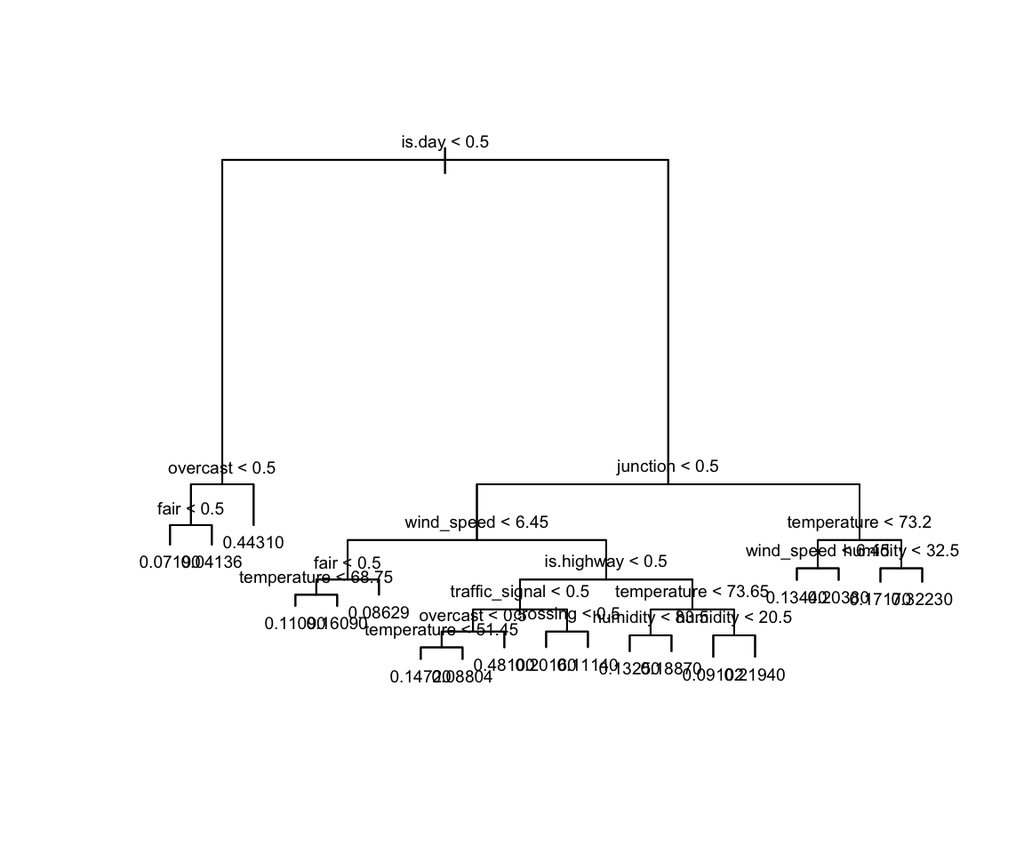

```r
accident.best.tree <- tree(severity ~ ., data=accident_tree[training,], mindev=best.mindev)
plot(accident.best.tree)
text(accident.best.tree, cex=0.6)
```

```r
table(accident.tree.classifications, accident_tree_test_results)
```

```
##                              accident_tree_test_results
## accident.tree.classifications  FALSE   TRUE
##                             0 263951  31295
```

**Classification tree analysis**